# Risk Factor Analysis

## Outcome Variable

**Outcome Variable:** ever_stunted

## Predictor Variables

**Intervention Variable:** exclfeed3

**Adjustment Set:**

unadjusted

## Stratifying Variables

The analysis was stratified on these variable(s):

- agecat
- studyid
- country

## Data Summary

| agecat | studyid | country | exclfeed3 | ever_stunted | n_cell | n |
| --- | --- | --- | --- | --- | --- | --- |
| 0-24 months (no birth st.) | CMC-V-BCS-2002 | INDIA | 1 | 0 | 0 | 8 |
| 0-24 months (no birth st.) | CMC-V-BCS-2002 | INDIA | 1 | 1 | 8 | 8 |
| 0-24 months (no birth st.) | CMC-V-BCS-2002 | INDIA | 0 | 0 | 0 | 8 |
| 0-24 months (no birth st.) | CMC-V-BCS-2002 | INDIA | 0 | 1 | 0 | 8 |
| 0-24 months (no birth st.) | EE | PAKISTAN | 1 | 0 | 4 | 21 |
| 0-24 months (no birth st.) | EE | PAKISTAN | 1 | 1 | 17 | 21 |
| 0-24 months (no birth st.) | EE | PAKISTAN | 0 | 0 | 0 | 21 |
| 0-24 months (no birth st.) | EE | PAKISTAN | 0 | 1 | 0 | 21 |
| 0-24 months (no birth st.) | GMS-Nepal | NEPAL | 1 | 0 | 116 | 380 |
| 0-24 months (no birth st.) | GMS-Nepal | NEPAL | 1 | 1 | 201 | 380 |
| 0-24 months (no birth st.) | GMS-Nepal | NEPAL | 0 | 0 | 22 | 380 |
| 0-24 months (no birth st.) | GMS-Nepal | NEPAL | 0 | 1 | 41 | 380 |
| 0-24 months (no birth st.) | IRC | INDIA | 1 | 0 | 0 | 10 |
| 0-24 months (no birth st.) | IRC | INDIA | 1 | 1 | 0 | 10 |
| 0-24 months (no birth st.) | IRC | INDIA | 0 | 0 | 3 | 10 |
| 0-24 months (no birth st.) | IRC | INDIA | 0 | 1 | 7 | 10 |
| 0-24 months (no birth st.) | Keneba | GAMBIA | 1 | 0 | 759 | 1835 |
| 0-24 months (no birth st.) | Keneba | GAMBIA | 1 | 1 | 874 | 1835 |
| 0-24 months (no birth st.) | Keneba | GAMBIA | 0 | 0 | 91 | 1835 |
| 0-24 months (no birth st.) | Keneba | GAMBIA | 0 | 1 | 111 | 1835 |
| 0-24 months (no birth st.) | MAL-ED | BANGLADESH | 1 | 0 | 61 | 202 |
| 0-24 months (no birth st.) | MAL-ED | BANGLADESH | 1 | 1 | 71 | 202 |
| 0-24 months (no birth st.) | MAL-ED | BANGLADESH | 0 | 0 | 33 | 202 |
| 0-24 months (no birth st.) | MAL-ED | BANGLADESH | 0 | 1 | 37 | 202 |
| 0-24 months (no birth st.) | MAL-ED | BRAZIL | 1 | 0 | 47 | 175 |
| 0-24 months (no birth st.) | MAL-ED | BRAZIL | 1 | 1 | 9 | 175 |
| 0-24 months (no birth st.) | MAL-ED | BRAZIL | 0 | 0 | 97 | 175 |
| 0-24 months (no birth st.) | MAL-ED | BRAZIL | 0 | 1 | 22 | 175 |
| 0-24 months (no birth st.) | MAL-ED | INDIA | 1 | 0 | 38 | 184 |
| 0-24 months (no birth st.) | MAL-ED | INDIA | 1 | 1 | 55 | 184 |

[output cut: 138 more lines]

The following strata were considered:

- agecat: 0-24 months (no birth st.), studyid: CMC-V-BCS-2002, country: INDIA
- agecat: 0-24 months (no birth st.), studyid: EE, country: PAKISTAN
- agecat: 0-24 months (no birth st.), studyid: GMS-Nepal, country: NEPAL
- agecat: 0-24 months (no birth st.), studyid: IRC, country: INDIA
- agecat: 0-24 months (no birth st.), studyid: Keneba, country: GAMBIA
- agecat: 0-24 months (no birth st.), studyid: MAL-ED, country: BANGLADESH
- agecat: 0-24 months (no birth st.), studyid: MAL-ED, country: BRAZIL
- agecat: 0-24 months (no birth st.), studyid: MAL-ED, country: INDIA
- agecat: 0-24 months (no birth st.), studyid: MAL-ED, country: NEPAL
- agecat: 0-24 months (no birth st.), studyid: MAL-ED, country: PERU
- agecat: 0-24 months (no birth st.), studyid: MAL-ED, country: SOUTH AFRICA
- agecat: 0-24 months (no birth st.), studyid: MAL-ED, country: TANZANIA, UNITED REPUBLIC OF
- agecat: 0-24 months (no birth st.), studyid: PROVIDE, country: BANGLADESH
- agecat: 0-24 months (no birth st.), studyid: SAS-CompFeed, country: INDIA
- agecat: 0-6 months (no birth st.), studyid: CMC-V-BCS-2002, country: INDIA
- agecat: 0-6 months (no birth st.), studyid: EE, country: PAKISTAN
- agecat: 0-6 months (no birth st.), studyid: GMS-Nepal, country: NEPAL
- agecat: 0-6 months (no birth st.), studyid: IRC, country: INDIA
- agecat: 0-6 months (no birth st.), studyid: Keneba, country: GAMBIA
- agecat: 0-6 months (no birth st.), studyid: MAL-ED, country: BANGLADESH
- agecat: 0-6 months (no birth st.), studyid: MAL-ED, country: BRAZIL
- agecat: 0-6 months (no birth st.), studyid: MAL-ED, country: INDIA
- agecat: 0-6 months (no birth st.), studyid: MAL-ED, country: NEPAL
- agecat: 0-6 months (no birth st.), studyid: MAL-ED, country: PERU
- agecat: 0-6 months (no birth st.), studyid: MAL-ED, country: SOUTH AFRICA
- agecat: 0-6 months (no birth st.), studyid: MAL-ED, country: TANZANIA, UNITED REPUBLIC OF
- agecat: 0-6 months (no birth st.), studyid: PROVIDE, country: BANGLADESH
- agecat: 0-6 months (no birth st.), studyid: SAS-CompFeed, country: INDIA
- agecat: 6-24 months, studyid: CMC-V-BCS-2002, country: INDIA
- agecat: 6-24 months, studyid: EE, country: PAKISTAN
- agecat: 6-24 months, studyid: GMS-Nepal, country: NEPAL
- agecat: 6-24 months, studyid: IRC, country: INDIA
- agecat: 6-24 months, studyid: Keneba, country: GAMBIA
- agecat: 6-24 months, studyid: MAL-ED, country: BANGLADESH
- agecat: 6-24 months, studyid: MAL-ED, country: BRAZIL
- agecat: 6-24 months, studyid: MAL-ED, country: INDIA
- agecat: 6-24 months, studyid: MAL-ED, country: NEPAL
- agecat: 6-24 months, studyid: MAL-ED, country: PERU
- agecat: 6-24 months, studyid: MAL-ED, country: SOUTH AFRICA
- agecat: 6-24 months, studyid: MAL-ED, country: TANZANIA, UNITED REPUBLIC OF
- agecat: 6-24 months, studyid: PROVIDE, country: BANGLADESH
- agecat: 6-24 months, studyid: SAS-CompFeed, country: INDIA

### Dropped Strata

Some strata were dropped due to rare outcomes:

- agecat: 0-24 months (no birth st.), studyid: CMC-V-BCS-2002, country: INDIA
- agecat: 0-24 months (no birth st.), studyid: EE, country: PAKISTAN
- agecat: 0-24 months (no birth st.), studyid: IRC, country: INDIA
- agecat: 0-6 months (no birth st.), studyid: CMC-V-BCS-2002, country: INDIA
- agecat: 0-6 months (no birth st.), studyid: EE, country: PAKISTAN
- agecat: 0-6 months (no birth st.), studyid: IRC, country: INDIA
- agecat: 0-6 months (no birth st.), studyid: MAL-ED, country: NEPAL
- agecat: 6-24 months, studyid: CMC-V-BCS-2002, country: INDIA
- agecat: 6-24 months, studyid: EE, country: PAKISTAN
- agecat: 6-24 months, studyid: IRC, country: INDIA
- agecat: 6-24 months, studyid: MAL-ED, country: BRAZIL
- agecat: 6-24 months, studyid: MAL-ED, country: SOUTH AFRICA
- agecat: 6-24 months, studyid: SAS-CompFeed, country: INDIA

## Methods Detail

We’re interested in the causal parameters $E[Y_a]$ for all values of $a \in \mathcal{A}$. These parameters represent the mean outcome if, possibly contrary to fact, we intervened to set all units to have $A=a$. Under the randomization and positivity assumptions, these are identified by the statistical parameters $\psi_a=E_W[E_{Y|A,W}(Y|A=a,W)]$. In addition, we’re interested in the mean of $Y$, $E[Y]$ under no intervention (the observed mean). We will estimate these parameters by using SuperLearner to fit the relevant likelihood factors – $E_{Y|A,W}(Y|A=a,W)$ and $p(A=a|W)$, and then updating our likelihood fit using a joint TMLE.

For unadjusted analyses ($W=\{\}$), initial likelihoods were estimated using Lrnr_glm to estimate the simple $E(Y|A)$ and Lrnr_mean to estimate $p(A)$. For adjusted analyses, a small library containing Lrnr_glmnet, Lrnr_xgboost, and Lrnr_mean was used.

Having estimated these parameters, we will then use the delta method to estimate relative risks and attributable risks relative to a prespecified baseline level of $A$.

# Results Detail

## Results Plots

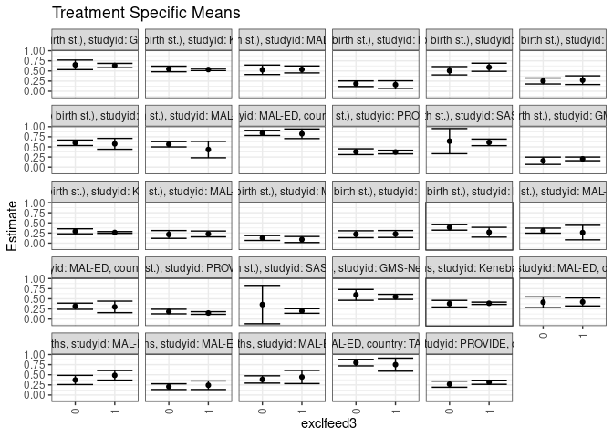

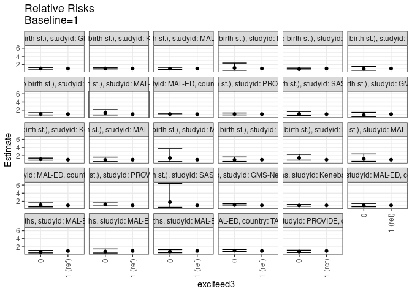

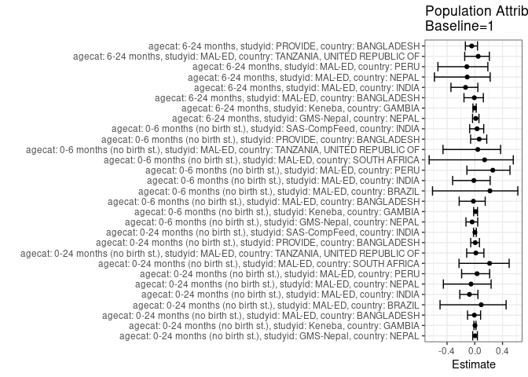

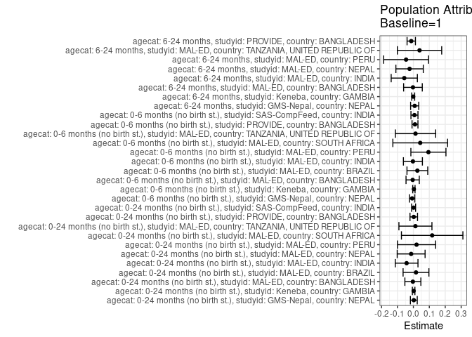

## Results Table

### Parameter: TSM

| agecat | studyid | country | intervention_level | baseline_level | estimate | ci_lower | ci_upper |
| --- | --- | --- | --- | --- | --- | --- | --- |
| 0-24 months (no birth st.) | GMS-Nepal | NEPAL | 1 | NA | 0.6340694 | 0.5809738 | 0.6871650 |
| 0-24 months (no birth st.) | GMS-Nepal | NEPAL | 0 | NA | 0.6507937 | 0.5329211 | 0.7686662 |
| 0-24 months (no birth st.) | Keneba | GAMBIA | 1 | NA | 0.5352113 | 0.5110141 | 0.5594084 |
| 0-24 months (no birth st.) | Keneba | GAMBIA | 0 | NA | 0.5495050 | 0.4808738 | 0.6181362 |
| 0-24 months (no birth st.) | MAL-ED | BANGLADESH | 1 | NA | 0.5378788 | 0.4526161 | 0.6231415 |
| 0-24 months (no birth st.) | MAL-ED | BANGLADESH | 0 | NA | 0.5285714 | 0.4113420 | 0.6458008 |
| 0-24 months (no birth st.) | MAL-ED | BRAZIL | 1 | NA | 0.1607143 | 0.0642469 | 0.2571817 |
| 0-24 months (no birth st.) | MAL-ED | BRAZIL | 0 | NA | 0.1848739 | 0.1149269 | 0.2548210 |
| 0-24 months (no birth st.) | MAL-ED | INDIA | 1 | NA | 0.5913978 | 0.4912180 | 0.6915777 |
| 0-24 months (no birth st.) | MAL-ED | INDIA | 0 | NA | 0.5054945 | 0.4024904 | 0.6084986 |
| 0-24 months (no birth st.) | MAL-ED | NEPAL | 1 | NA | 0.2727273 | 0.1650133 | 0.3804413 |
| 0-24 months (no birth st.) | MAL-ED | NEPAL | 0 | NA | 0.2518519 | 0.1784460 | 0.3252577 |
| 0-24 months (no birth st.) | MAL-ED | PERU | 1 | NA | 0.5769231 | 0.4423758 | 0.7114704 |
| 0-24 months (no birth st.) | MAL-ED | PERU | 0 | NA | 0.6019900 | 0.5341866 | 0.6697935 |
| 0-24 months (no birth st.) | MAL-ED | SOUTH AFRICA | 1 | NA | 0.4347826 | 0.2317592 | 0.6378060 |
| 0-24 months (no birth st.) | MAL-ED | SOUTH AFRICA | 0 | NA | 0.5654206 | 0.4988657 | 0.6319754 |
| 0-24 months (no birth st.) | MAL-ED | TANZANIA, UNITED REPUBLIC OF | 1 | NA | 0.8250000 | 0.7069296 | 0.9430704 |
| 0-24 months (no birth st.) | MAL-ED | TANZANIA, UNITED REPUBLIC OF | 0 | NA | 0.8413793 | 0.7817559 | 0.9010027 |
| 0-24 months (no birth st.) | PROVIDE | BANGLADESH | 1 | NA | 0.3736264 | 0.3291406 | 0.4181122 |
| 0-24 months (no birth st.) | PROVIDE | BANGLADESH | 0 | NA | 0.3820225 | 0.3105873 | 0.4534577 |
| 0-24 months (no birth st.) | SAS-CompFeed | INDIA | 1 | NA | 0.6121795 | 0.5306906 | 0.6936683 |
| 0-24 months (no birth st.) | SAS-CompFeed | INDIA | 0 | NA | 0.6428571 | 0.3329177 | 0.9527966 |
| 0-6 months (no birth st.) | GMS-Nepal | NEPAL | 1 | NA | 0.2050473 | 0.1605444 | 0.2495502 |
| 0-6 months (no birth st.) | GMS-Nepal | NEPAL | 0 | NA | 0.1587302 | 0.0683762 | 0.2490842 |
| 0-6 months (no birth st.) | Keneba | GAMBIA | 1 | NA | 0.2633190 | 0.2419515 | 0.2846866 |
| 0-6 months (no birth st.) | Keneba | GAMBIA | 0 | NA | 0.2920792 | 0.2293553 | 0.3548032 |
| 0-6 months (no birth st.) | MAL-ED | BANGLADESH | 1 | NA | 0.2272727 | 0.1556047 | 0.2989408 |
| 0-6 months (no birth st.) | MAL-ED | BANGLADESH | 0 | NA | 0.2142857 | 0.1179237 | 0.3106477 |
| 0-6 months (no birth st.) | MAL-ED | BRAZIL | 1 | NA | 0.0892857 | 0.0143859 | 0.1641855 |
| 0-6 months (no birth st.) | MAL-ED | BRAZIL | 0 | NA | 0.1260504 | 0.0662459 | 0.1858550 |
| 0-6 months (no birth st.) | MAL-ED | INDIA | 1 | NA | 0.2258065 | 0.1405979 | 0.3110150 |
| 0-6 months (no birth st.) | MAL-ED | INDIA | 0 | NA | 0.2197802 | 0.1344675 | 0.3050929 |
| 0-6 months (no birth st.) | MAL-ED | PERU | 1 | NA | 0.2692308 | 0.1484330 | 0.3900285 |
| 0-6 months (no birth st.) | MAL-ED | PERU | 0 | NA | 0.3880597 | 0.3205581 | 0.4555613 |
| 0-6 months (no birth st.) | MAL-ED | SOUTH AFRICA | 1 | NA | 0.2608696 | 0.0810344 | 0.4407047 |
| 0-6 months (no birth st.) | MAL-ED | SOUTH AFRICA | 0 | NA | 0.3084112 | 0.2464031 | 0.3704193 |
| 0-6 months (no birth st.) | MAL-ED | TANZANIA, UNITED REPUBLIC OF | 1 | NA | 0.3000000 | 0.1576017 | 0.4423983 |
| 0-6 months (no birth st.) | MAL-ED | TANZANIA, UNITED REPUBLIC OF | 0 | NA | 0.3172414 | 0.2412841 | 0.3931987 |
| 0-6 months (no birth st.) | PROVIDE | BANGLADESH | 1 | NA | 0.1494505 | 0.1166649 | 0.1822362 |
| 0-6 months (no birth st.) | PROVIDE | BANGLADESH | 0 | NA | 0.1853933 | 0.1282582 | 0.2425283 |
| 0-6 months (no birth st.) | SAS-CompFeed | INDIA | 1 | NA | 0.1987179 | 0.1419130 | 0.2555229 |
| 0-6 months (no birth st.) | SAS-CompFeed | INDIA | 0 | NA | 0.3571429 | -0.1170496 | 0.8313354 |
| 6-24 months | GMS-Nepal | NEPAL | 1 | NA | 0.5483871 | 0.4863468 | 0.6104274 |
| 6-24 months | GMS-Nepal | NEPAL | 0 | NA | 0.5961538 | 0.4625686 | 0.7297391 |
| 6-24 months | Keneba | GAMBIA | 1 | NA | 0.3891323 | 0.3608316 | 0.4174331 |
| 6-24 months | Keneba | GAMBIA | 0 | NA | 0.3795620 | 0.2982699 | 0.4608541 |
| 6-24 months | MAL-ED | BANGLADESH | 1 | NA | 0.4226804 | 0.3240459 | 0.5213149 |
| 6-24 months | MAL-ED | BANGLADESH | 0 | NA | 0.4150943 | 0.2819941 | 0.5481946 |
| 6-24 months | MAL-ED | INDIA | 1 | NA | 0.4857143 | 0.3682114 | 0.6032171 |
| 6-24 months | MAL-ED | INDIA | 0 | NA | 0.3714286 | 0.2578306 | 0.4850266 |
| 6-24 months | MAL-ED | NEPAL | 1 | NA | 0.2419355 | 0.1350514 | 0.3488196 |
| 6-24 months | MAL-ED | NEPAL | 0 | NA | 0.2063492 | 0.1354997 | 0.2771988 |
| 6-24 months | MAL-ED | PERU | 1 | NA | 0.4444444 | 0.2815743 | 0.6073146 |
| 6-24 months | MAL-ED | PERU | 0 | NA | 0.3839286 | 0.2935528 | 0.4743043 |
| 6-24 months | MAL-ED | TANZANIA, UNITED REPUBLIC OF | 1 | NA | 0.7500000 | 0.5889568 | 0.9110432 |
| 6-24 months | MAL-ED | TANZANIA, UNITED REPUBLIC OF | 0 | NA | 0.8000000 | 0.7192358 | 0.8807642 |
| 6-24 months | PROVIDE | BANGLADESH | 1 | NA | 0.3138462 | 0.2633391 | 0.3643532 |
| 6-24 months | PROVIDE | BANGLADESH | 0 | NA | 0.2671756 | 0.1913200 | 0.3430311 |

### Parameter: E(Y)

| agecat | studyid | country | intervention_level | baseline_level | estimate | ci_lower | ci_upper |
| --- | --- | --- | --- | --- | --- | --- | --- |
| 0-24 months (no birth st.) | GMS-Nepal | NEPAL | NA | NA | 0.6368421 | 0.5884257 | 0.6852585 |
| 0-24 months (no birth st.) | Keneba | GAMBIA | NA | NA | 0.5367847 | 0.5139635 | 0.5596060 |
| 0-24 months (no birth st.) | MAL-ED | BANGLADESH | NA | NA | 0.5346535 | 0.4656971 | 0.6036099 |
| 0-24 months (no birth st.) | MAL-ED | BRAZIL | NA | NA | 0.1771429 | 0.1204149 | 0.2338709 |
| 0-24 months (no birth st.) | MAL-ED | INDIA | NA | NA | 0.5489130 | 0.4768182 | 0.6210079 |
| 0-24 months (no birth st.) | MAL-ED | NEPAL | NA | NA | 0.2587065 | 0.1980144 | 0.3193985 |
| 0-24 months (no birth st.) | MAL-ED | PERU | NA | NA | 0.5968379 | 0.5362738 | 0.6574021 |
| 0-24 months (no birth st.) | MAL-ED | SOUTH AFRICA | NA | NA | 0.5527426 | 0.4893071 | 0.6161781 |
| 0-24 months (no birth st.) | MAL-ED | TANZANIA, UNITED REPUBLIC OF | NA | NA | 0.8378378 | 0.7845787 | 0.8910970 |
| 0-24 months (no birth st.) | PROVIDE | BANGLADESH | NA | NA | 0.3759874 | 0.3382238 | 0.4137509 |
| 0-24 months (no birth st.) | SAS-CompFeed | INDIA | NA | NA | 0.6134969 | 0.5286303 | 0.6983636 |
| 0-6 months (no birth st.) | GMS-Nepal | NEPAL | NA | NA | 0.1973684 | 0.1572979 | 0.2374390 |
| 0-6 months (no birth st.) | Keneba | GAMBIA | NA | NA | 0.2664850 | 0.2462507 | 0.2867194 |
| 0-6 months (no birth st.) | MAL-ED | BANGLADESH | NA | NA | 0.2227723 | 0.1652475 | 0.2802970 |
| 0-6 months (no birth st.) | MAL-ED | BRAZIL | NA | NA | 0.1142857 | 0.0670124 | 0.1615591 |
| 0-6 months (no birth st.) | MAL-ED | INDIA | NA | NA | 0.2228261 | 0.1625334 | 0.2831188 |
| 0-6 months (no birth st.) | MAL-ED | PERU | NA | NA | 0.3636364 | 0.3042435 | 0.4230292 |
| 0-6 months (no birth st.) | MAL-ED | SOUTH AFRICA | NA | NA | 0.3037975 | 0.2451226 | 0.3624723 |
| 0-6 months (no birth st.) | MAL-ED | TANZANIA, UNITED REPUBLIC OF | NA | NA | 0.3135135 | 0.2464813 | 0.3805457 |
| 0-6 months (no birth st.) | PROVIDE | BANGLADESH | NA | NA | 0.1595577 | 0.1310079 | 0.1881074 |
| 0-6 months (no birth st.) | SAS-CompFeed | INDIA | NA | NA | 0.2055215 | 0.1385538 | 0.2724891 |
| 6-24 months | GMS-Nepal | NEPAL | NA | NA | 0.5566667 | 0.5003580 | 0.6129753 |
| 6-24 months | Keneba | GAMBIA | NA | NA | 0.3881064 | 0.3613784 | 0.4148344 |
| 6-24 months | MAL-ED | BANGLADESH | NA | NA | 0.4200000 | 0.3407510 | 0.4992490 |
| 6-24 months | MAL-ED | INDIA | NA | NA | 0.4285714 | 0.3463030 | 0.5108399 |
| 6-24 months | MAL-ED | NEPAL | NA | NA | 0.2180851 | 0.1588990 | 0.2772712 |
| 6-24 months | MAL-ED | PERU | NA | NA | 0.3986486 | 0.3194990 | 0.4777982 |
| 6-24 months | MAL-ED | TANZANIA, UNITED REPUBLIC OF | NA | NA | 0.7886179 | 0.7161684 | 0.8610674 |
| 6-24 months | PROVIDE | BANGLADESH | NA | NA | 0.3004386 | 0.2583143 | 0.3425629 |

### Parameter: RR

| agecat | studyid | country | intervention_level | baseline_level | estimate | ci_lower | ci_upper |
| --- | --- | --- | --- | --- | --- | --- | --- |
| 0-24 months (no birth st.) | GMS-Nepal | NEPAL | 1 | 1 | 1.0000000 | 1.0000000 | 1.000000 |
| 0-24 months (no birth st.) | GMS-Nepal | NEPAL | 0 | 1 | 1.0263761 | 0.8407108 | 1.253044 |
| 0-24 months (no birth st.) | Keneba | GAMBIA | 1 | 1 | 1.0000000 | 1.0000000 | 1.000000 |
| 0-24 months (no birth st.) | Keneba | GAMBIA | 0 | 1 | 1.0267066 | 0.8990010 | 1.172553 |
| 0-24 months (no birth st.) | MAL-ED | BANGLADESH | 1 | 1 | 1.0000000 | 1.0000000 | 1.000000 |
| 0-24 months (no birth st.) | MAL-ED | BANGLADESH | 0 | 1 | 0.9826962 | 0.7482147 | 1.290661 |
| 0-24 months (no birth st.) | MAL-ED | BRAZIL | 1 | 1 | 1.0000000 | 1.0000000 | 1.000000 |
| 0-24 months (no birth st.) | MAL-ED | BRAZIL | 0 | 1 | 1.1503268 | 0.5658150 | 2.338665 |
| 0-24 months (no birth st.) | MAL-ED | INDIA | 1 | 1 | 1.0000000 | 1.0000000 | 1.000000 |
| 0-24 months (no birth st.) | MAL-ED | INDIA | 0 | 1 | 0.8547453 | 0.6557762 | 1.114084 |
| 0-24 months (no birth st.) | MAL-ED | NEPAL | 1 | 1 | 1.0000000 | 1.0000000 | 1.000000 |
| 0-24 months (no birth st.) | MAL-ED | NEPAL | 0 | 1 | 0.9234568 | 0.5652509 | 1.508662 |
| 0-24 months (no birth st.) | MAL-ED | PERU | 1 | 1 | 1.0000000 | 1.0000000 | 1.000000 |
| 0-24 months (no birth st.) | MAL-ED | PERU | 0 | 1 | 1.0434494 | 0.8053670 | 1.351914 |
| 0-24 months (no birth st.) | MAL-ED | SOUTH AFRICA | 1 | 1 | 1.0000000 | 1.0000000 | 1.000000 |
| 0-24 months (no birth st.) | MAL-ED | SOUTH AFRICA | 0 | 1 | 1.3004673 | 0.8034522 | 2.104936 |
| 0-24 months (no birth st.) | MAL-ED | TANZANIA, UNITED REPUBLIC OF | 1 | 1 | 1.0000000 | 1.0000000 | 1.000000 |
| 0-24 months (no birth st.) | MAL-ED | TANZANIA, UNITED REPUBLIC OF | 0 | 1 | 1.0198537 | 0.8693236 | 1.196449 |
| 0-24 months (no birth st.) | PROVIDE | BANGLADESH | 1 | 1 | 1.0000000 | 1.0000000 | 1.000000 |
| 0-24 months (no birth st.) | PROVIDE | BANGLADESH | 0 | 1 | 1.0224719 | 0.8191747 | 1.276222 |
| 0-24 months (no birth st.) | SAS-CompFeed | INDIA | 1 | 1 | 1.0000000 | 1.0000000 | 1.000000 |
| 0-24 months (no birth st.) | SAS-CompFeed | INDIA | 0 | 1 | 1.0501122 | 0.6736522 | 1.636951 |
| 0-6 months (no birth st.) | GMS-Nepal | NEPAL | 1 | 1 | 1.0000000 | 1.0000000 | 1.000000 |
| 0-6 months (no birth st.) | GMS-Nepal | NEPAL | 0 | 1 | 0.7741148 | 0.4209513 | 1.423570 |
| 0-6 months (no birth st.) | Keneba | GAMBIA | 1 | 1 | 1.0000000 | 1.0000000 | 1.000000 |
| 0-6 months (no birth st.) | Keneba | GAMBIA | 0 | 1 | 1.1092217 | 0.8816931 | 1.395466 |
| 0-6 months (no birth st.) | MAL-ED | BANGLADESH | 1 | 1 | 1.0000000 | 1.0000000 | 1.000000 |
| 0-6 months (no birth st.) | MAL-ED | BANGLADESH | 0 | 1 | 0.9428571 | 0.5443974 | 1.632961 |
| 0-6 months (no birth st.) | MAL-ED | BRAZIL | 1 | 1 | 1.0000000 | 1.0000000 | 1.000000 |
| 0-6 months (no birth st.) | MAL-ED | BRAZIL | 0 | 1 | 1.4117647 | 0.5385303 | 3.700961 |
| 0-6 months (no birth st.) | MAL-ED | INDIA | 1 | 1 | 1.0000000 | 1.0000000 | 1.000000 |
| 0-6 months (no birth st.) | MAL-ED | INDIA | 0 | 1 | 0.9733124 | 0.5664243 | 1.672487 |
| 0-6 months (no birth st.) | MAL-ED | PERU | 1 | 1 | 1.0000000 | 1.0000000 | 1.000000 |
| 0-6 months (no birth st.) | MAL-ED | PERU | 0 | 1 | 1.4413646 | 0.8908087 | 2.332186 |
| 0-6 months (no birth st.) | MAL-ED | SOUTH AFRICA | 1 | 1 | 1.0000000 | 1.0000000 | 1.000000 |
| 0-6 months (no birth st.) | MAL-ED | SOUTH AFRICA | 0 | 1 | 1.1822430 | 0.5765601 | 2.424203 |
| 0-6 months (no birth st.) | MAL-ED | TANZANIA, UNITED REPUBLIC OF | 1 | 1 | 1.0000000 | 1.0000000 | 1.000000 |
| 0-6 months (no birth st.) | MAL-ED | TANZANIA, UNITED REPUBLIC OF | 0 | 1 | 1.0574713 | 0.6214194 | 1.799502 |
| 0-6 months (no birth st.) | PROVIDE | BANGLADESH | 1 | 1 | 1.0000000 | 1.0000000 | 1.000000 |
| 0-6 months (no birth st.) | PROVIDE | BANGLADESH | 0 | 1 | 1.2404990 | 0.8497828 | 1.810860 |
| 0-6 months (no birth st.) | SAS-CompFeed | INDIA | 1 | 1 | 1.0000000 | 1.0000000 | 1.000000 |
| 0-6 months (no birth st.) | SAS-CompFeed | INDIA | 0 | 1 | 1.7972350 | 0.5064696 | 6.377587 |
| 6-24 months | GMS-Nepal | NEPAL | 1 | 1 | 1.0000000 | 1.0000000 | 1.000000 |
| 6-24 months | GMS-Nepal | NEPAL | 0 | 1 | 1.0871041 | 0.8457759 | 1.397291 |
| 6-24 months | Keneba | GAMBIA | 1 | 1 | 1.0000000 | 1.0000000 | 1.000000 |
| 6-24 months | Keneba | GAMBIA | 0 | 1 | 0.9754061 | 0.7779553 | 1.222971 |
| 6-24 months | MAL-ED | BANGLADESH | 1 | 1 | 1.0000000 | 1.0000000 | 1.000000 |
| 6-24 months | MAL-ED | BANGLADESH | 0 | 1 | 0.9820525 | 0.6605483 | 1.460040 |
| 6-24 months | MAL-ED | INDIA | 1 | 1 | 1.0000000 | 1.0000000 | 1.000000 |
| 6-24 months | MAL-ED | INDIA | 0 | 1 | 0.7647059 | 0.5177741 | 1.129402 |
| 6-24 months | MAL-ED | NEPAL | 1 | 1 | 1.0000000 | 1.0000000 | 1.000000 |
| 6-24 months | MAL-ED | NEPAL | 0 | 1 | 0.8529101 | 0.4874232 | 1.492452 |
| 6-24 months | MAL-ED | PERU | 1 | 1 | 1.0000000 | 1.0000000 | 1.000000 |
| 6-24 months | MAL-ED | PERU | 0 | 1 | 0.8638393 | 0.5588255 | 1.335333 |
| 6-24 months | MAL-ED | TANZANIA, UNITED REPUBLIC OF | 1 | 1 | 1.0000000 | 1.0000000 | 1.000000 |
| 6-24 months | MAL-ED | TANZANIA, UNITED REPUBLIC OF | 0 | 1 | 1.0666667 | 0.8413610 | 1.352306 |
| 6-24 months | PROVIDE | BANGLADESH | 1 | 1 | 1.0000000 | 1.0000000 | 1.000000 |
| 6-24 months | PROVIDE | BANGLADESH | 0 | 1 | 0.8512947 | 0.6142515 | 1.179814 |

### Parameter: PAR

| agecat | studyid | country | intervention_level | baseline_level | estimate | ci_lower | ci_upper |
| --- | --- | --- | --- | --- | --- | --- | --- |
| 0-24 months (no birth st.) | GMS-Nepal | NEPAL | 1 | NA | 0.0027727 | -0.0186696 | 0.0242150 |
| 0-24 months (no birth st.) | Keneba | GAMBIA | 1 | NA | 0.0015735 | -0.0064400 | 0.0095869 |
| 0-24 months (no birth st.) | MAL-ED | BANGLADESH | 1 | NA | -0.0032253 | -0.0534616 | 0.0470109 |
| 0-24 months (no birth st.) | MAL-ED | BRAZIL | 1 | NA | 0.0164286 | -0.0646159 | 0.0974731 |
| 0-24 months (no birth st.) | MAL-ED | INDIA | 1 | NA | -0.0424848 | -0.1138191 | 0.0288495 |
| 0-24 months (no birth st.) | MAL-ED | NEPAL | 1 | NA | -0.0140208 | -0.1015788 | 0.0735372 |
| 0-24 months (no birth st.) | MAL-ED | PERU | 1 | NA | 0.0199149 | -0.0997909 | 0.1396206 |
| 0-24 months (no birth st.) | MAL-ED | SOUTH AFRICA | 1 | NA | 0.1179600 | -0.0750228 | 0.3109428 |
| 0-24 months (no birth st.) | MAL-ED | TANZANIA, UNITED REPUBLIC OF | 1 | NA | 0.0128378 | -0.0908385 | 0.1165141 |
| 0-24 months (no birth st.) | PROVIDE | BANGLADESH | 1 | NA | 0.0023610 | -0.0213051 | 0.0260271 |
| 0-24 months (no birth st.) | SAS-CompFeed | INDIA | 1 | NA | 0.0013174 | -0.0112602 | 0.0138950 |
| 0-6 months (no birth st.) | GMS-Nepal | NEPAL | 1 | NA | -0.0076789 | -0.0244669 | 0.0091091 |
| 0-6 months (no birth st.) | Keneba | GAMBIA | 1 | NA | 0.0031660 | -0.0041401 | 0.0104720 |
| 0-6 months (no birth st.) | MAL-ED | BANGLADESH | 1 | NA | -0.0045005 | -0.0461250 | 0.0371241 |
| 0-6 months (no birth st.) | MAL-ED | BRAZIL | 1 | NA | 0.0250000 | -0.0402255 | 0.0902255 |
| 0-6 months (no birth st.) | MAL-ED | INDIA | 1 | NA | -0.0029804 | -0.0626150 | 0.0566543 |
| 0-6 months (no birth st.) | MAL-ED | PERU | 1 | NA | 0.0944056 | -0.0156911 | 0.2045023 |
| 0-6 months (no birth st.) | MAL-ED | SOUTH AFRICA | 1 | NA | 0.0429279 | -0.1288462 | 0.2147020 |
| 0-6 months (no birth st.) | MAL-ED | TANZANIA, UNITED REPUBLIC OF | 1 | NA | 0.0135135 | -0.1129856 | 0.1400126 |
| 0-6 months (no birth st.) | PROVIDE | BANGLADESH | 1 | NA | 0.0101071 | -0.0084593 | 0.0286736 |
| 0-6 months (no birth st.) | SAS-CompFeed | INDIA | 1 | NA | 0.0068035 | -0.0151879 | 0.0287949 |
| 6-24 months | GMS-Nepal | NEPAL | 1 | NA | 0.0082796 | -0.0173326 | 0.0338918 |
| 6-24 months | Keneba | GAMBIA | 1 | NA | -0.0010259 | -0.0102548 | 0.0082029 |
| 6-24 months | MAL-ED | BANGLADESH | 1 | NA | -0.0026804 | -0.0612178 | 0.0558570 |
| 6-24 months | MAL-ED | INDIA | 1 | NA | -0.0571429 | -0.1394113 | 0.0251256 |
| 6-24 months | MAL-ED | NEPAL | 1 | NA | -0.0238504 | -0.1098277 | 0.0621269 |
| 6-24 months | MAL-ED | PERU | 1 | NA | -0.0457958 | -0.1868152 | 0.0952236 |
| 6-24 months | MAL-ED | TANZANIA, UNITED REPUBLIC OF | 1 | NA | 0.0386179 | -0.1005801 | 0.1778159 |
| 6-24 months | PROVIDE | BANGLADESH | 1 | NA | -0.0134076 | -0.0396598 | 0.0128447 |

### Parameter: PAF

| agecat | studyid | country | intervention_level | baseline_level | estimate | ci_lower | ci_upper |
| --- | --- | --- | --- | --- | --- | --- | --- |
| 0-24 months (no birth st.) | GMS-Nepal | NEPAL | 1 | NA | 0.0043538 | -0.0298958 | 0.0374645 |
| 0-24 months (no birth st.) | Keneba | GAMBIA | 1 | NA | 0.0029313 | -0.0121104 | 0.0177494 |
| 0-24 months (no birth st.) | MAL-ED | BANGLADESH | 1 | NA | -0.0060325 | -0.1045253 | 0.0836774 |
| 0-24 months (no birth st.) | MAL-ED | BRAZIL | 1 | NA | 0.0927419 | -0.5012539 | 0.4517136 |
| 0-24 months (no birth st.) | MAL-ED | INDIA | 1 | NA | -0.0773981 | -0.2162422 | 0.0455958 |
| 0-24 months (no birth st.) | MAL-ED | NEPAL | 1 | NA | -0.0541958 | -0.4531947 | 0.2352513 |
| 0-24 months (no birth st.) | MAL-ED | PERU | 1 | NA | 0.0333673 | -0.1895895 | 0.2145368 |
| 0-24 months (no birth st.) | MAL-ED | SOUTH AFRICA | 1 | NA | 0.2134086 | -0.2273337 | 0.4958779 |
| 0-24 months (no birth st.) | MAL-ED | TANZANIA, UNITED REPUBLIC OF | 1 | NA | 0.0153226 | -0.1165714 | 0.1316367 |
| 0-24 months (no birth st.) | PROVIDE | BANGLADESH | 1 | NA | 0.0062794 | -0.0587014 | 0.0672719 |
| 0-24 months (no birth st.) | SAS-CompFeed | INDIA | 1 | NA | 0.0021474 | -0.0184658 | 0.0223435 |
| 0-6 months (no birth st.) | GMS-Nepal | NEPAL | 1 | NA | -0.0389064 | -0.1273497 | 0.0425983 |
| 0-6 months (no birth st.) | Keneba | GAMBIA | 1 | NA | 0.0118805 | -0.0159154 | 0.0389159 |
| 0-6 months (no birth st.) | MAL-ED | BANGLADESH | 1 | NA | -0.0202020 | -0.2252185 | 0.1505090 |
| 0-6 months (no birth st.) | MAL-ED | BRAZIL | 1 | NA | 0.2187500 | -0.6101023 | 0.6209237 |
| 0-6 months (no birth st.) | MAL-ED | INDIA | 1 | NA | -0.0133753 | -0.3196582 | 0.2218216 |
| 0-6 months (no birth st.) | MAL-ED | PERU | 1 | NA | 0.2596154 | -0.1137442 | 0.5078140 |
| 0-6 months (no birth st.) | MAL-ED | SOUTH AFRICA | 1 | NA | 0.1413043 | -0.6585343 | 0.5554157 |
| 0-6 months (no birth st.) | MAL-ED | TANZANIA, UNITED REPUBLIC OF | 1 | NA | 0.0431034 | -0.4587646 | 0.3723107 |
| 0-6 months (no birth st.) | PROVIDE | BANGLADESH | 1 | NA | 0.0633446 | -0.0601509 | 0.1724542 |
| 0-6 months (no birth st.) | SAS-CompFeed | INDIA | 1 | NA | 0.0331037 | -0.0733606 | 0.1290081 |
| 6-24 months | GMS-Nepal | NEPAL | 1 | NA | 0.0148735 | -0.0322658 | 0.0598601 |
| 6-24 months | Keneba | GAMBIA | 1 | NA | -0.0026434 | -0.0267069 | 0.0208561 |
| 6-24 months | MAL-ED | BANGLADESH | 1 | NA | -0.0063819 | -0.1558719 | 0.1237743 |
| 6-24 months | MAL-ED | INDIA | 1 | NA | -0.1333333 | -0.3439190 | 0.0442546 |
| 6-24 months | MAL-ED | NEPAL | 1 | NA | -0.1093627 | -0.5821338 | 0.2221356 |
| 6-24 months | MAL-ED | PERU | 1 | NA | -0.1148776 | -0.5316621 | 0.1884946 |
| 6-24 months | MAL-ED | TANZANIA, UNITED REPUBLIC OF | 1 | NA | 0.0489691 | -0.1454021 | 0.2103561 |
| 6-24 months | PROVIDE | BANGLADESH | 1 | NA | -0.0446266 | -0.1357400 | 0.0391773 |